# practical_exercise_1, Methods 3, 2021, autumn semester

# Prepare your *R* and *Python* environments

Today’s first goal is to get your *R* and *Python* environments up and running

## *R*

### Mac and Windows

*R* can be downloaded and installed from https://mirrors.dotsrc.org/cran/ (Danish mirror)

### Linux

Can also be installed from the link above, but it is more convenient to use your package manager, e.g.

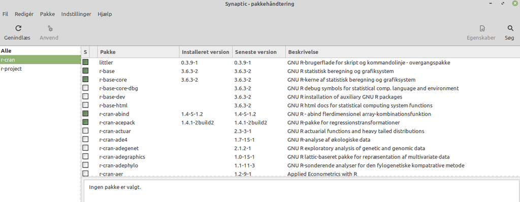

### *RStudio* (IDE: Integrated Development Editor)

*RStudio* can be downloaded from https://www.rstudio.com/products/rstudio/download/

### Packages

We need the package *lme4* for specifying mixed effects models

```r
install.packages("lme4")
## but can also be installed from the package manager (Linux) (r-cran-lme4)
```

## *Python*

An advantage is that separate environments can be maintained that are each focused on its own niche:

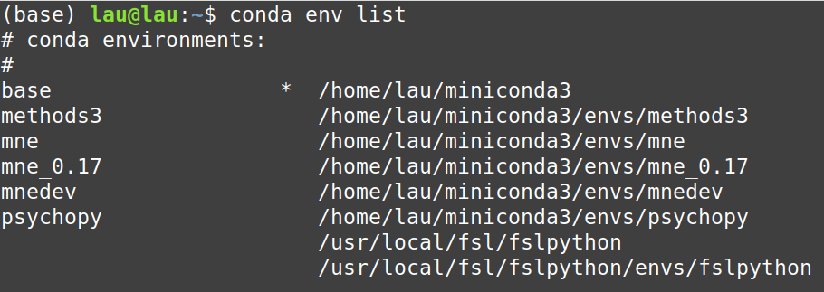

**Figure**: my environments: *mne* is for analysis of magnetoencephalographic data, *psychopy* is for presenting experiment scenarios, *fsl* is for processing magnetic resonance imaging data

Then use the yml-file from GitHub to create the appropriate environment:

```bash
# CODE TO BE RUN IN A BASH TERMINAL
## create environment
conda env create -f methods3_environment.yml
## activate environment
conda activate methods3
## after activation, you can run Spyder, (IDE)
spyder
```

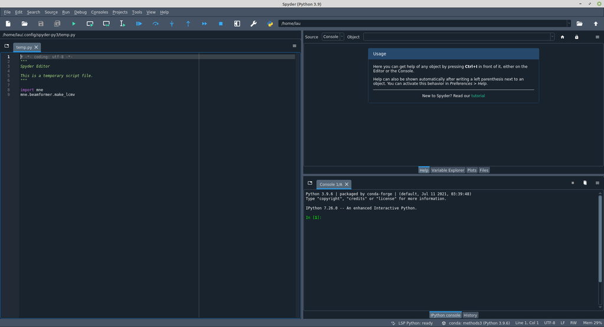

**Figure**: *Spyder*

### Check that it works

```python
a = 2 + 2
b = a + 3
print(b)
```

```
## 7
```

```python
a_list = [1, 'a', 2.3] # square brackets initialize lists that can contain any combination of any type of object (an integer, a string and a float in this case)
## Note that Python is zero-indexed ()
print(a_list[0]) ## prints the first entry
```

```
## 1
```

```python
print(a_list[1]) ## prints the second entry
```

```
## a
```

#### zero-indexing (reference)

https://www.cs.utexas.edu/users/EWD/transcriptions/EWD08xx/EWD831.html

# Remembering the General Linear Model

## Formulae

```r
formula <- y ~ x ## y as a function of x
y ~ 1 ## model the intercept for "y"
y ~ x ## model the main effect of x and the intercept for y
y ~ x + 1 ## the same as above (+ 1 is implicit)
y ~ x + 0 ## model the main effect of x and no intercept
y ~ x - 1 ## the same as above
y ~ 0 ## doesn't model anything (for completeness)
y ~ x + z ## model the main effects x and z (and an intercept)
y ~ x:z ## model interaction of x and z
y ~ x * z ## model the main effects x and z and their interaction
y ~ x + z + x:z ## the same as above
```

## mtcars (data)

[, 1] mpg Miles/(US) gallon  
[, 2] cyl Number of cylinders  
[, 3] disp Displacement (cu.in.)  
[, 4] hp Gross horsepower  
[, 5] drat Rear axle ratio  
[, 6] wt Weight (lb/1000)  
[, 7] qsec 1/4 mile time  
[, 8] vs V/S  
[, 9] am Transmission (0 = automatic, 1 = manual)  
[,10] gear Number of forward gears  
[,11] carb Number of carburetors

## Miles per gallon and weight

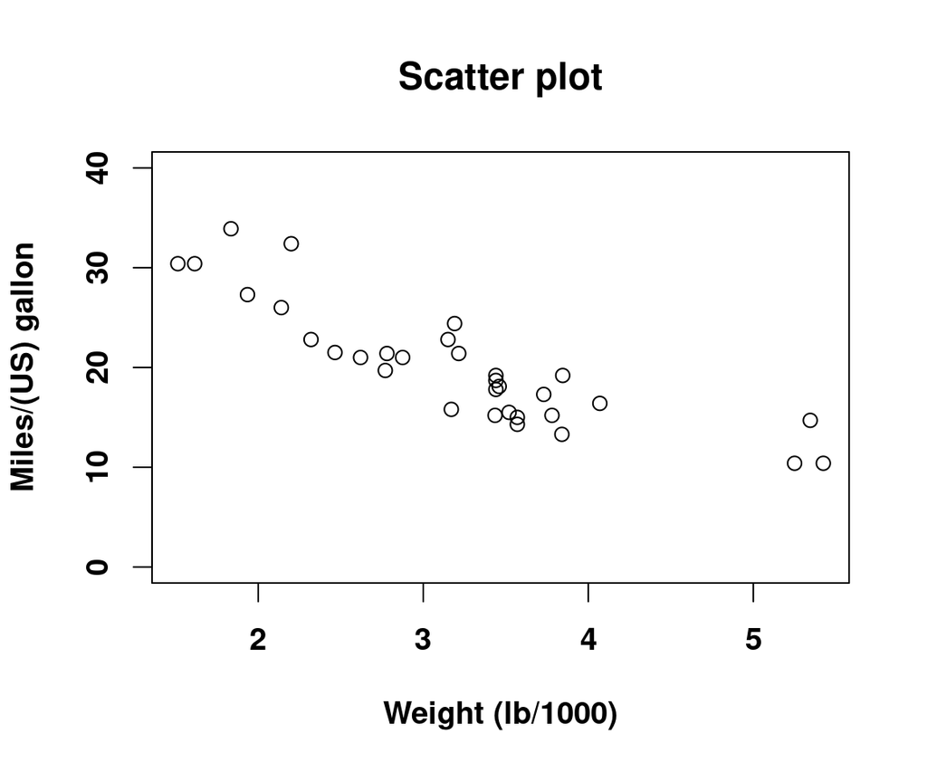

```r
par(font.lab=2, font.axis=2, cex=1.2)
plot(mpg ~ wt, data=mtcars, xlab='Weight (lb/1000)', ylab='Miles/(US) gallon',
     main='Scatter plot', ylim=c(0, 40))
```

Let’s do a linear regression

## Now let’s create some models!

```r
linear <- lm(mpg ~ wt, data=mtcars)
quadratic <- lm(mpg ~ I(wt^2) + wt, data=mtcars)
cubic <- lm(mpg ~ I(wt^3) + I(wt^2) + wt, data=mtcars)
```

## Plotting, linear

```
## 'log Lik.' -80.01471 (df=3)
```

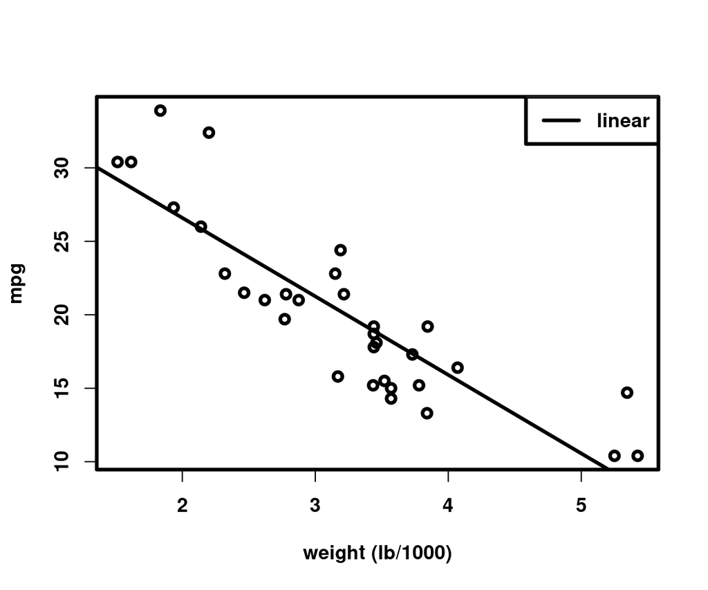

## Plotting, quadratic

```
## 'log Lik.' -75.0242 (df=4)
```

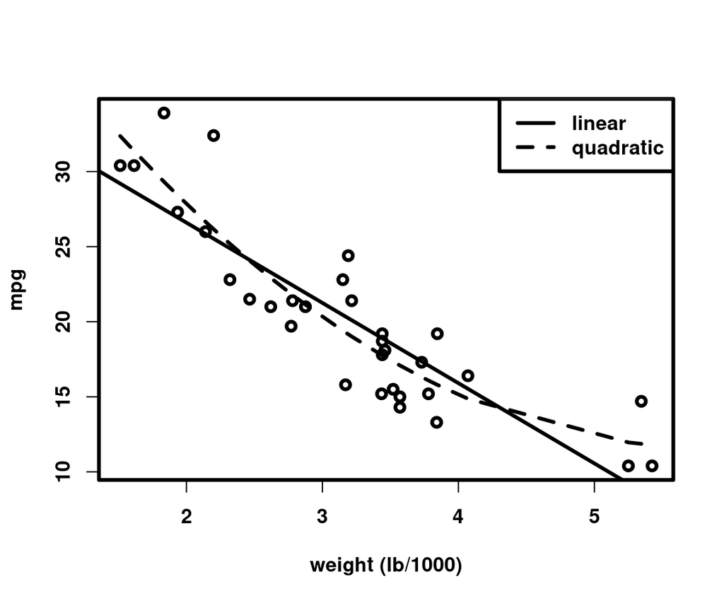

## Plotting, cubic

```
## 'log Lik.' -75.01827 (df=5)
```

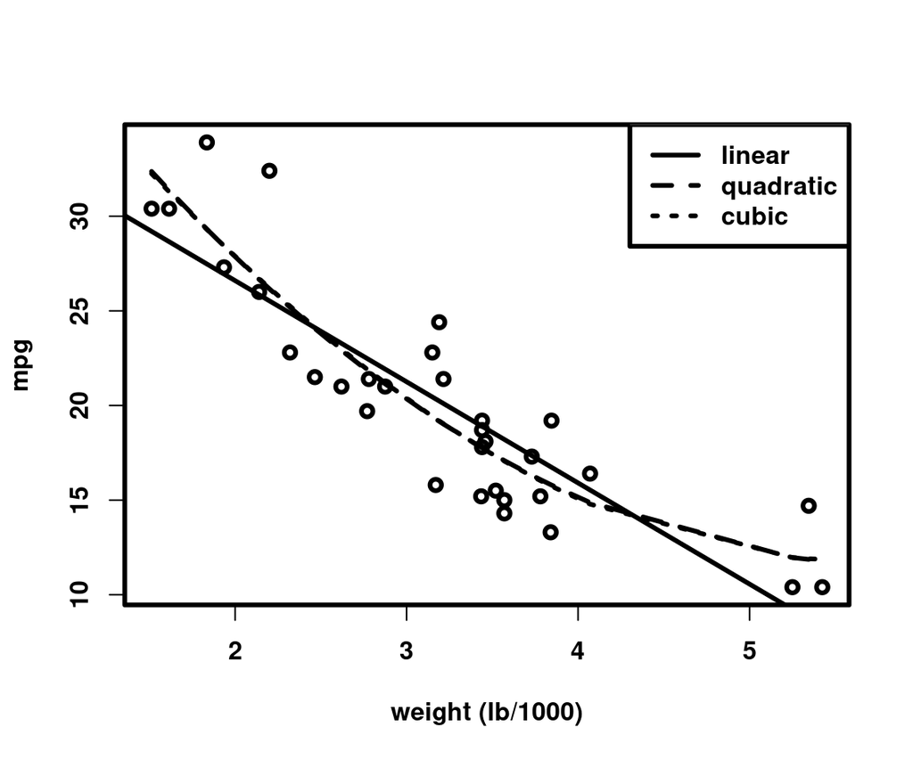